# Customers RFM Clustering (Market Segmentation based on Behavioral Approach)

Mohammad Ali Momen

05/13/2023

**Data Analysis methodology**: CRISP-DM

**Dataset**: Iranian online e-commerce platform’s customers transactions data in first 4 months of year 1398 (from 1398/01/01 to 1398/04/31)

**Case Goal**: Detect and Segment similar customers of e-commerce platform business (Customer Segmentation using RFM model)

# 1 Required Libraries

```r
library('factoextra')
library('ggplot2')
library('cluster')
```

# 2 Read Data from File

```r
data <- read.csv('CS_09.csv', header = T)
dim(data)  # 40537 records, 5 variables
```

```
## [1] 40537     5
```

# 3 Business Understanding

- know business process and issues
- know the context of the problem
- know the order of numbers in the business

# 4 Data Understanding

## 4.1 Data Inspection

Data Understanding from Free Perspective

### 4.1.1 Dataset variables definition

```r
colnames(data)
```

```
## [1] "order_id"       "created_ts"     "shamsy_date"    "customer_id"
## [5] "total_purchase"
```

- **order_id**: ID of customer’s order (Transaction unique ID)
- **created_ts**: Date of ordering in EN (date of Transaction)
- **shamsy_date**: Date of ordering in FA
- **customer_id**: ID of customer
- **total_purchase**: sum of purchase for ordering transaction (Transaction total payment Price in Rials)

## 4.2 Data Exploring

Data Understanding from Statistical Perspective

### 4.2.1 Overview of Dataframe

```r
class(data)
```

```
## [1] "data.frame"
```

```r
head(data)
```

|  | order_id | created_ts | shamsy_date | customer_id | total_purchase |
| --- | --- | --- | --- | --- | --- |
| 1 | 5c92a3d9a7b11b0001e4ec46 | 3/21/2019 0:04 | 1398-Farvardin-1 | 5bf1092b24aa9a000135ac7c | 240000 |
| 2 | 5c92af8024aa9a00015b536d | 3/21/2019 0:54 | 1398-Farvardin-1 | 58d2fe9b46e0fb0001e432c0 | 620000 |
| 3 | 5c930b0ea7b11b0001e4f07e | 3/21/2019 7:24 | 1398-Farvardin-1 | 5c85f140a7b11b0001e65ec1 | 320000 |
| 4 | 5c93157324aa9a00015b5750 | 3/21/2019 8:09 | 1398-Farvardin-1 | 59c52fe152faff00014e4932 | 220000 |
| 5 | 5c93250024aa9a00015b5884 | 3/21/2019 9:15 | 1398-Farvardin-1 | 58eba26fd601800001b98a34 | 360000 |
| 6 | 5c93262ca7b11b0001e4f271 | 3/21/2019 9:20 | 1398-Farvardin-1 | 5c84876fa7b11b0001e58d09 | 360000 |

```r
tail(data)
```

|  | order_id | created_ts | shamsy_date | customer_id | total_purchase |
| --- | --- | --- | --- | --- | --- |
| 40532 | 5d35fa09b2cf38d2d17b1113 | 7/22/2019 22:31 | 1398-Tir-31 | 5a2147b9d6018000013b864d | 320000 |
| 40533 | 5d35fd03b2cf38d2d17b11c9 | 7/22/2019 22:44 | 1398-Tir-31 | 58d2972b46e0fb0001e42133 | 280000 |
| 40534 | 5d35fe44ec2c893461deb4e0 | 7/22/2019 22:49 | 1398-Tir-31 | 597009a6c9e77c00018c27d9 | 300000 |
| 40535 | 5d35ff28b2cf38d2d17b1228 | 7/22/2019 22:53 | 1398-Tir-31 | 59222bce52faff00016c59cc | 180000 |
| 40536 | 5d360499b2cf38d2d17b12f6 | 7/22/2019 23:16 | 1398-Tir-31 | 5d19f78ab2cf38e5e4deddd6 | 180000 |
| 40537 | 5d360b2eec2c893461deb667 | 7/22/2019 23:44 | 1398-Tir-31 | 5c46e8fe24aa9a00019af009 | 180000 |

```r
str(data)
```

```
## 'data.frame':    40537 obs. of  5 variables:
##  $ order_id      : chr  "5c92a3d9a7b11b0001e4ec46" "5c92af8024aa9a00015b536d" "5c930b0ea7b11b0001e4f07e" "5c93157324aa9a00015b5750" ...
##  $ created_ts    : chr  "3/21/2019 0:04" "3/21/2019 0:54" "3/21/2019 7:24" "3/21/2019 8:09" ...
##  $ shamsy_date   : chr  "1398-Farvardin-1" "1398-Farvardin-1" "1398-Farvardin-1" "1398-Farvardin-1" ...
##  $ customer_id   : chr  "5bf1092b24aa9a000135ac7c" "58d2fe9b46e0fb0001e432c0" "5c85f140a7b11b0001e65ec1" "59c52fe152faff00014e4932" ...
##  $ total_purchase: num  240000 620000 320000 220000 360000 360000 520000 400000 180000 280000 ...
```

```r
summary(data)
```

```
##    order_id          created_ts        shamsy_date        customer_id
##  Length:40537       Length:40537       Length:40537       Length:40537
##  Class :character   Class :character   Class :character   Class :character
##  Mode  :character   Mode  :character   Mode  :character   Mode  :character
##
##
##
##  total_purchase
##  Min.   :  80000
##  1st Qu.: 260000
##  Median : 320000
##  Mean   : 348802
##  3rd Qu.: 420000
##  Max.   :3200000
```

```r
sum(is.na(data$total_purchase))  # has NA?
```

```
## [1] 0
```

### 4.2.2 Analyze daily demand (analyze number of transactions per day):

```r
data$date <- as.Date(data$created_ts, '%m/%d/%Y')  # convert Character to Date
class(data$date)
```

```
## [1] "Date"
```

```r
daily_demand <- table(data$date)  # count records (transactions|demand) in each Category (day|date)
head(daily_demand)
```

```
##
## 2019-03-21 2019-03-22 2019-03-23 2019-03-24 2019-03-25 2019-03-26
##         33         21         38         27         73         85
```

```r
mean(daily_demand)  # average daily transactions of this Business: 327 transactions in a day
```

```
## [1] 326.9113
```

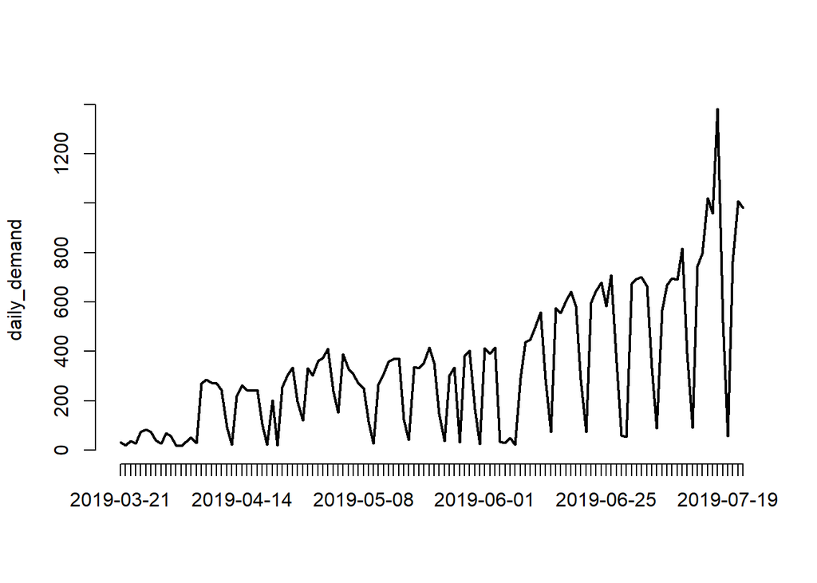

```r
plot(daily_demand, type = 'l')  # line chart: daily-demand changes through time
```

- There is a seasonal pattern in daily-demand of this business
  - we have demand fall in weekends and holidays in this Business (because of Nature of demand)
  - we have a pick in last week because of marketing campaign

# 5 Data PreProcessing

## 5.1 Create RFM dataset

We want to use RFM model for our Cluestering, so we need to prepare Recency-Frequency-Monetary for every customer at this analysis-time-range

### 5.1.1 Frequency: number of purchases per customer at analysis-time-range

```r
customer_f <- as.data.frame(aggregate(data$order_id, list(data$customer_id), length))  # count number of transactions per customer_id in 4 months
colnames(customer_f) <- c('customer_id', 'freq')
head(customer_f)
```

|  | customer_id | freq |
| --- | --- | --- |
| 1 | 5.94687E+23 | 2 |
| 2 | 5.94772E+23 | 1 |
| 3 | 5.94773E+23 | 5 |
| 4 | 5.95E+25 | 1 |
| 5 | 58a4b0e452faff000179dbd0 | 7 |
| 6 | 58a56a6b52faff00013072d8 | 4 |

```r
length(customer_f$customer_id)  # 14964
```

```
## [1] 14964
```

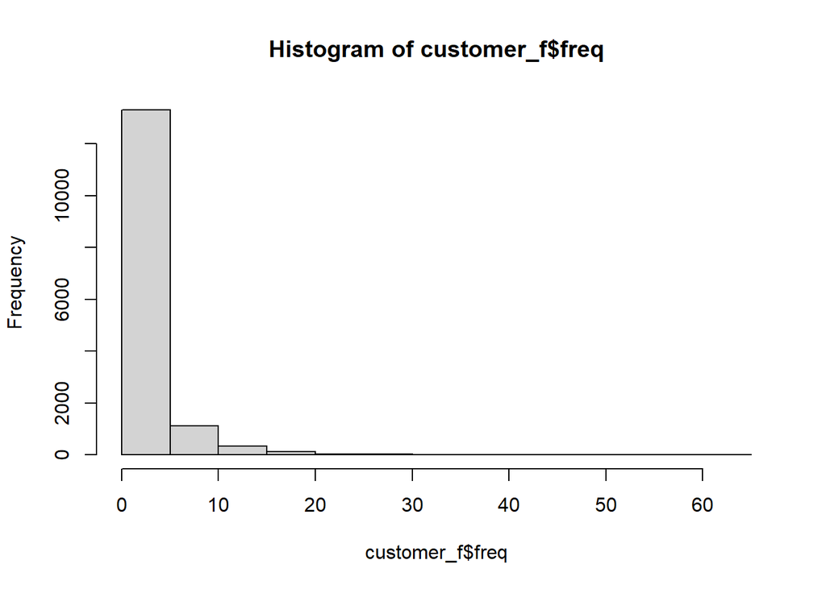

```r
hist(customer_f$freq, breks = 50)
```

```r
summary(customer_f$freq)
```

```
##    Min. 1st Qu.  Median    Mean 3rd Qu.    Max.
##   1.000   1.000   1.000   2.709   3.000  61.000
```

### 5.1.2 Recency: how long it passed from a customer’s last purchase time?

```r
tail(data)
```

|  | order_id | created_ts | shamsy_date | customer_id | total_purchase | date |
| --- | --- | --- | --- | --- | --- | --- |
| 40532 | 5d35fa09b2cf38d2d17b1113 | 7/22/2019 22:31 | 1398-Tir-31 | 5a2147b9d6018000013b864d | 320000 | 2019-07-22 |
| 40533 | 5d35fd03b2cf38d2d17b11c9 | 7/22/2019 22:44 | 1398-Tir-31 | 58d2972b46e0fb0001e42133 | 280000 | 2019-07-22 |
| 40534 | 5d35fe44ec2c893461deb4e0 | 7/22/2019 22:49 | 1398-Tir-31 | 597009a6c9e77c00018c27d9 | 300000 | 2019-07-22 |
| 40535 | 5d35ff28b2cf38d2d17b1228 | 7/22/2019 22:53 | 1398-Tir-31 | 59222bce52faff00016c59cc | 180000 | 2019-07-22 |
| 40536 | 5d360499b2cf38d2d17b12f6 | 7/22/2019 23:16 | 1398-Tir-31 | 5d19f78ab2cf38e5e4deddd6 | 180000 | 2019-07-22 |
| 40537 | 5d360b2eec2c893461deb667 | 7/22/2019 23:44 | 1398-Tir-31 | 5c46e8fe24aa9a00019af009 | 180000 | 2019-07-22 |

```r
r_date <- as.Date("07/23/2019", format = "%m/%d/%Y")  # reference date
customer_r <- as.data.frame(aggregate(data$date, list(data$customer_id), max))  # last date per each customer_id
colnames(customer_r) <- c('customer_id', 'last_date')
head(customer_r)  # last transaction date per customer_id
```

|  | customer_id | last_date |
| --- | --- | --- |
| 1 | 5.94687E+23 | 2019-07-14 |
| 2 | 5.94772E+23 | 2019-05-20 |
| 3 | 5.94773E+23 | 2019-07-14 |
| 4 | 5.95E+25 | 2019-07-18 |
| 5 | 58a4b0e452faff000179dbd0 | 2019-07-16 |
| 6 | 58a56a6b52faff00013072d8 | 2019-06-16 |

```r
customer_r$recency <- as.numeric(r_date - customer_r$last_date)  # difference between two date in days
head(customer_r)  # passed days from each customer's last purchase?
```

|  | customer_id | last_date | recency |
| --- | --- | --- | --- |
| 1 | 5.94687E+23 | 2019-07-14 | 9 |
| 2 | 5.94772E+23 | 2019-05-20 | 64 |
| 3 | 5.94773E+23 | 2019-07-14 | 9 |
| 4 | 5.95E+25 | 2019-07-18 | 5 |
| 5 | 58a4b0e452faff000179dbd0 | 2019-07-16 | 7 |
| 6 | 58a56a6b52faff00013072d8 | 2019-06-16 | 37 |

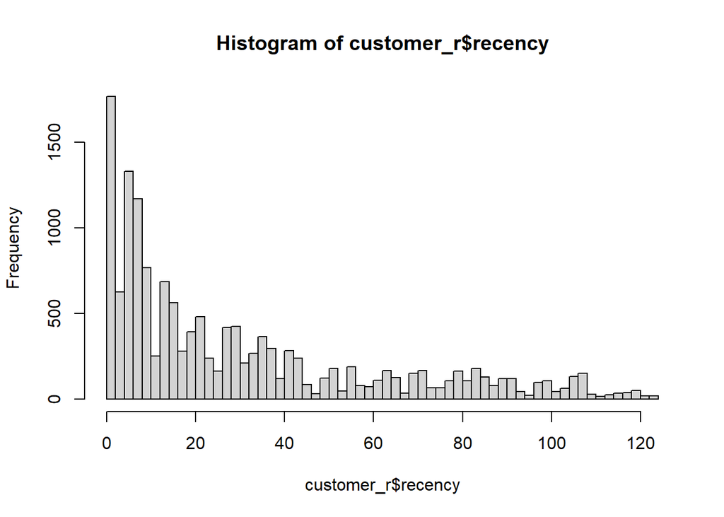

```r
hist(customer_r$recency, breaks = 50)
```

```r
summary(customer_r$recency)
```

```
##    Min. 1st Qu.  Median    Mean 3rd Qu.    Max.
##     1.0     7.0    19.0    30.5    43.0   124.0
```

### 5.1.3 Monetary: total purchase per customer

```r
customer_m <- as.data.frame(aggregate(data$total_purchase, list(data$customer_id), sum))  # total purchase per customer_id in 4 months in Rials
colnames(customer_m) <- c('customer_id', 'monetary')
head(customer_m)
```

|  | customer_id | monetary |
| --- | --- | --- |
| 1 | 5.94687E+23 | 680000 |
| 2 | 5.94772E+23 | 600000 |
| 3 | 5.94773E+23 | 1700000 |
| 4 | 5.95E+25 | 320000 |
| 5 | 58a4b0e452faff000179dbd0 | 1480000 |
| 6 | 58a56a6b52faff00013072d8 | 1220000 |

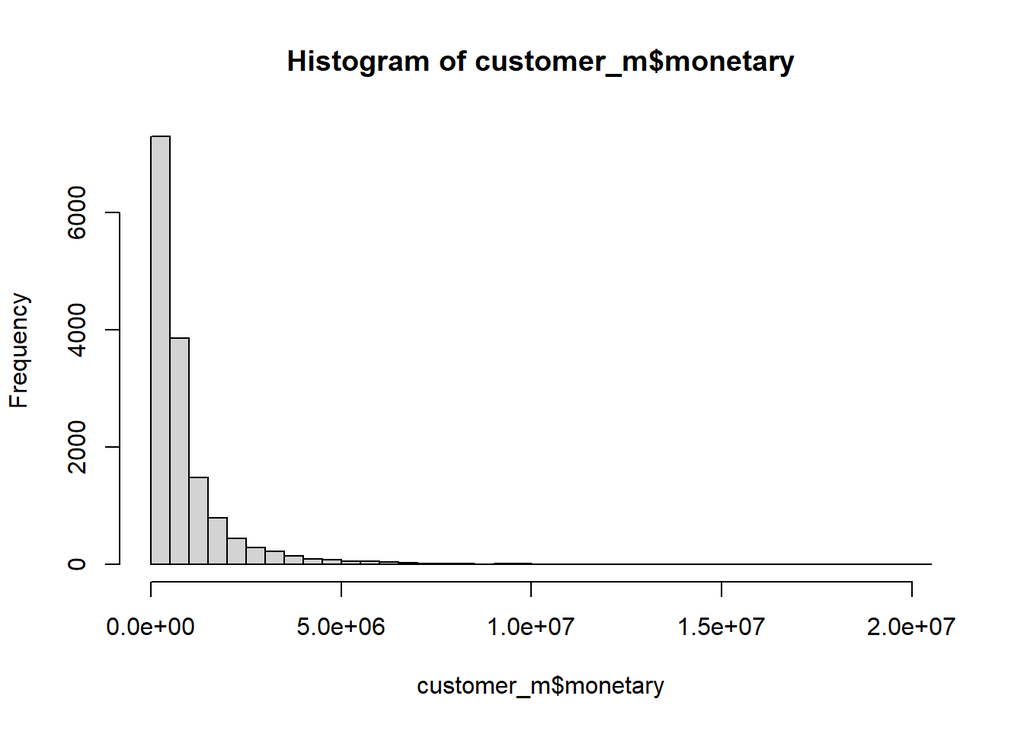

```r
hist(customer_m$monetary, breaks = 50)
```

```r
summary(customer_m$monetary)
```

```
##     Min.  1st Qu.   Median     Mean  3rd Qu.     Max.
##    80000   320000   520000   944894  1040000 20420000
```

### 5.1.4 RFM dataset for Customers

```r
df <- merge(customer_f, customer_r, 'customer_id')  # merge two dataframe based-on 'customer_id' column
head(df)
```

|  | customer_id | freq | last_date | recency |
| --- | --- | --- | --- | --- |
| 1 | 5.94687E+23 | 2 | 2019-07-14 | 9 |
| 2 | 5.94772E+23 | 1 | 2019-05-20 | 64 |
| 3 | 5.94773E+23 | 5 | 2019-07-14 | 9 |
| 4 | 5.95E+25 | 1 | 2019-07-18 | 5 |
| 5 | 58a4b0e452faff000179dbd0 | 7 | 2019-07-16 | 7 |
| 6 | 58a56a6b52faff00013072d8 | 4 | 2019-06-16 | 37 |

```r
rfm_customer <- merge(df, customer_m, 'customer_id')
head(rfm_customer)
```

|  | customer_id | freq | last_date | recency | monetary |
| --- | --- | --- | --- | --- | --- |
| 1 | 5.94687E+23 | 2 | 2019-07-14 | 9 | 680000 |
| 2 | 5.94772E+23 | 1 | 2019-05-20 | 64 | 600000 |
| 3 | 5.94773E+23 | 5 | 2019-07-14 | 9 | 1700000 |
| 4 | 5.95E+25 | 1 | 2019-07-18 | 5 | 320000 |
| 5 | 58a4b0e452faff000179dbd0 | 7 | 2019-07-16 | 7 | 1480000 |
| 6 | 58a56a6b52faff00013072d8 | 4 | 2019-06-16 | 37 | 1220000 |

```r
rfm_customer <- rfm_customer[, -3]  # remove 'last_date'
head(rfm_customer)  # R-F-M per each customer
```

|  | customer_id | freq | recency | monetary |
| --- | --- | --- | --- | --- |
| 1 | 5.94687E+23 | 2 | 9 | 680000 |
| 2 | 5.94772E+23 | 1 | 64 | 600000 |
| 3 | 5.94773E+23 | 5 | 9 | 1700000 |
| 4 | 5.95E+25 | 1 | 5 | 320000 |
| 5 | 58a4b0e452faff000179dbd0 | 7 | 7 | 1480000 |
| 6 | 58a56a6b52faff00013072d8 | 4 | 37 | 1220000 |

```r
rownames(rfm_customer) <- rfm_customer$customer_id  # assign customer ids to row names
rfm_customer <- rfm_customer[,-1]  # remove 'customer_id'
head(rfm_customer)
```

|  | freq | recency | monetary |
| --- | --- | --- | --- |
| 5.94687E+23 | 2 | 9 | 680000 |
| 5.94772E+23 | 1 | 64 | 600000 |
| 5.94773E+23 | 5 | 9 | 1700000 |
| 5.95E+25 | 1 | 5 | 320000 |
| 58a4b0e452faff000179dbd0 | 7 | 7 | 1480000 |
| 58a56a6b52faff00013072d8 | 4 | 37 | 1220000 |

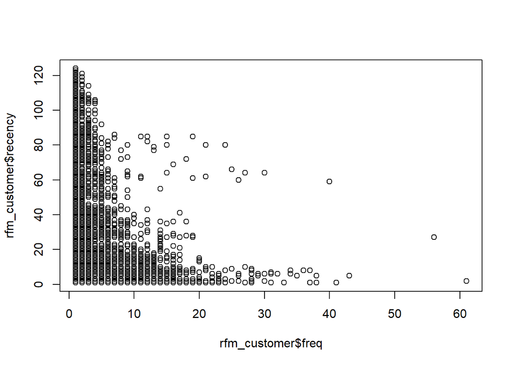

```r
plot(rfm_customer$freq, rfm_customer$recency)  # there is not any pattern
```

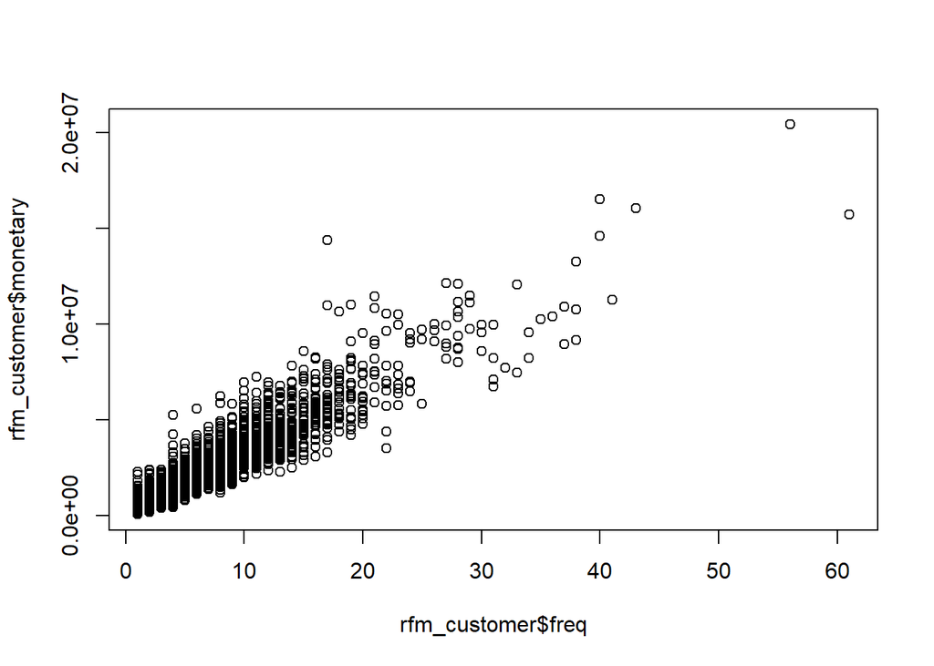

```r
plot(rfm_customer$freq, rfm_customer$monetary)  # there is a Strong positive linear-relationship between two features
```

```r
cor(rfm_customer$freq, rfm_customer$monetary)  # high correlation
```

```
## [1] 0.9477864
```

```r
rfm_customer_2 <- rfm_customer[,c('freq', 'recency')]  # remove 'monetary' column from our Clustering features
head(rfm_customer_2)
```

|  | freq | recency |
| --- | --- | --- |
| 5.94687E+23 | 2 | 9 |
| 5.94772E+23 | 1 | 64 |
| 5.94773E+23 | 5 | 9 |
| 5.95E+25 | 1 | 5 |
| 58a4b0e452faff000179dbd0 | 7 | 7 |
| 58a56a6b52faff00013072d8 | 4 | 37 |

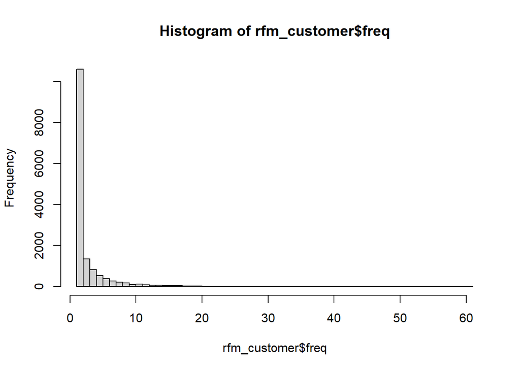

```r
hist(rfm_customer$freq, breaks = 50)  # so skewed data
```

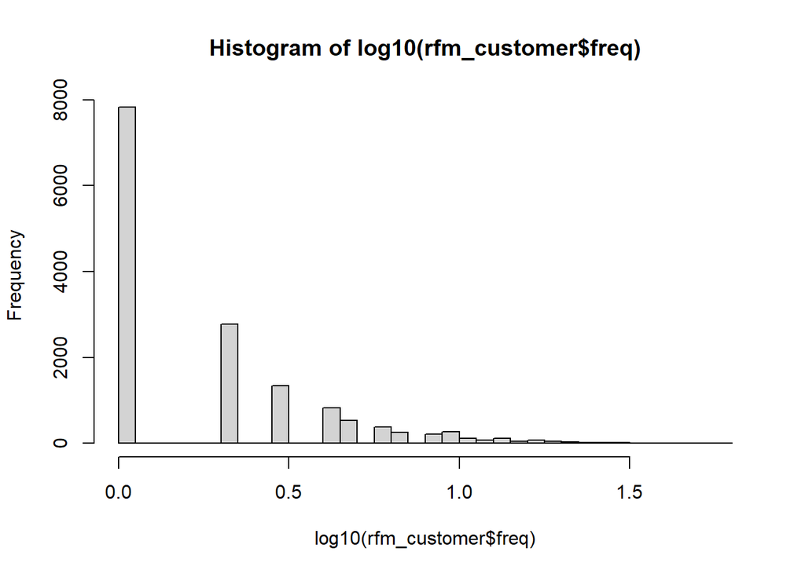

```r
hist(log10(rfm_customer$freq), breaks = 50)  # still skewed log(data)
```

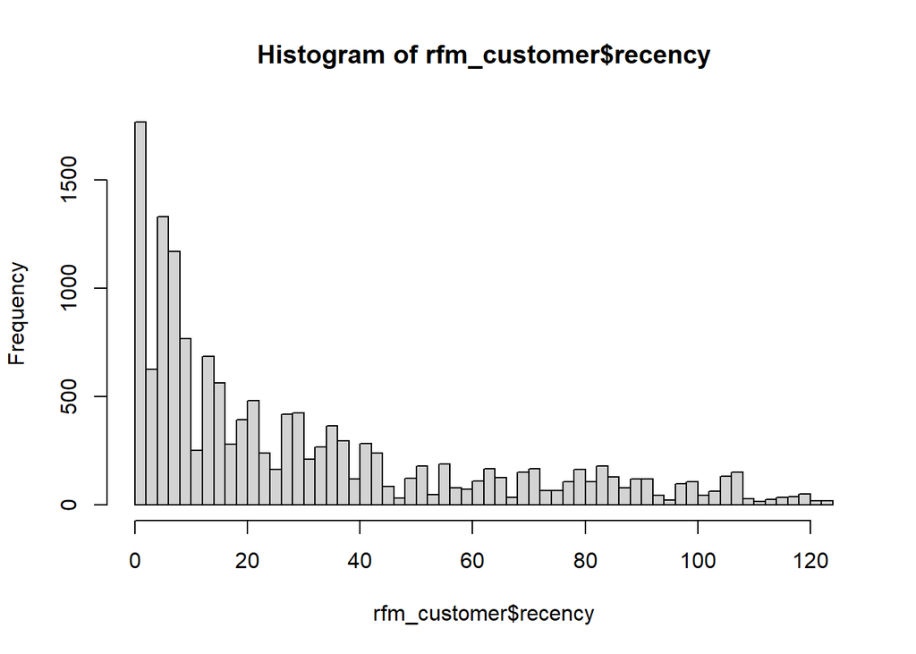

```r
hist(rfm_customer$recency, breaks = 50)
```

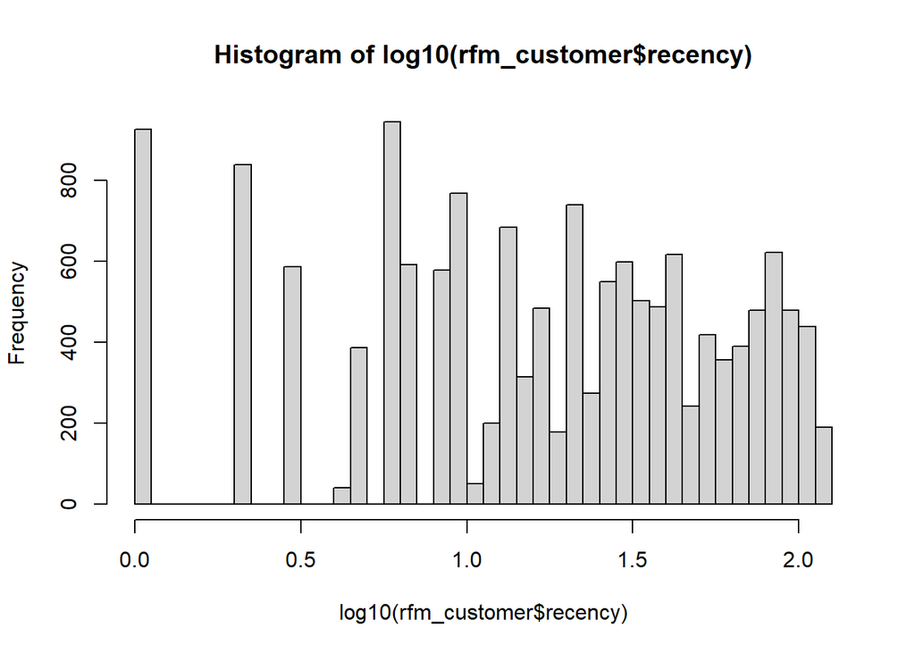

```r
hist(log10(rfm_customer$recency), breaks = 50)
```

### 5.1.5 Scale features

```r
rfm_customer_2 <- scale(rfm_customer_2)  # bring data around 0
head(rfm_customer_2)
```

```
##                                freq    recency
## 5.94687E+23              -0.2069731 -0.6972374
## 5.94772E+23              -0.4989088  1.0865595
## 5.94773E+23               0.6688340 -0.6972374
## 5.95E+25                 -0.4989088 -0.8269681
## 58a4b0e452faff000179dbd0  1.2527054 -0.7621028
## 58a56a6b52faff00013072d8  0.3768983  0.2108774
```

```r
summary(rfm_customer_2)
```

```
##       freq             recency
##  Min.   :-0.49891   Min.   :-0.9567
##  1st Qu.:-0.49891   1st Qu.:-0.7621
##  Median :-0.49891   Median :-0.3729
##  Mean   : 0.00000   Mean   : 0.0000
##  3rd Qu.: 0.08496   3rd Qu.: 0.4055
##  Max.   :17.01723   Max.   : 3.0325
```

```r
class(rfm_customer_2)
```

```
## [1] "matrix" "array"
```

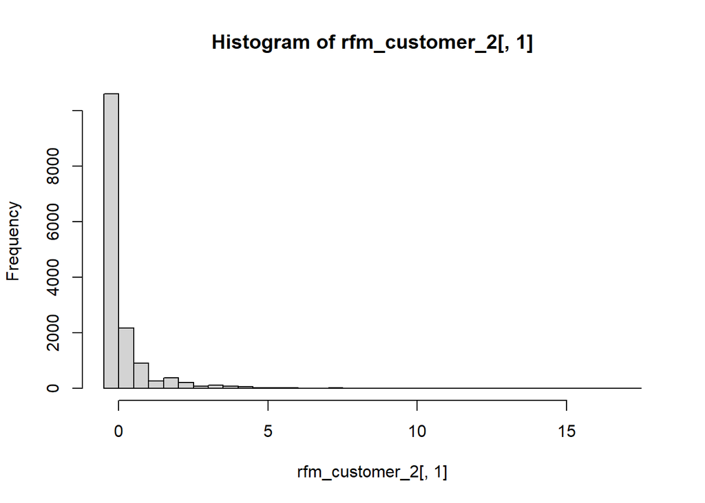

```r
hist(rfm_customer_2[,1], breaks = 50) #skewed data
```

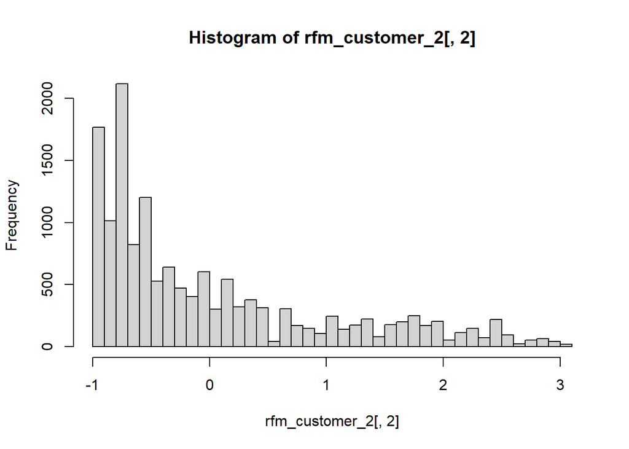

```r
hist(rfm_customer_2[,2], breaks = 50) #skewed data
```

# 6 Modeling

## 6.1 Model 1: K-Means

### 6.1.1 First try

```r
set.seed(123)
seg_km1 <- kmeans(rfm_customer_2, centers = 5)  # 5 clusters
seg_km1
```

[output not shown]

[output cut: 9941 more lines]

[output not shown]

### 6.1.2 Results

```r
seg_km1$cluster  # each observation (customer) is in which cluster?
```

[output not shown]

[output cut: 9921 more lines]

[output not shown]

```r
table(seg_km1$cluster)  # each cluster's population
```

```
##
##    1    2    3    4    5
## 2563  557 6034 2245 3565
```

```r
km_res1 <- as.data.frame(seg_km1$cluster)
km_res1$customer_id <- rownames(km_res1)  # add 'customer_id' column again
colnames(km_res1) <- c('cluster', 'customer_id')
head(km_res1)
```

|  | cluster | customer_id |
| --- | --- | --- |
| 5.94687E+23 | 3 | 5.94687E+23 |
| 5.94772E+23 | 1 | 5.94772E+23 |
| 5.94773E+23 | 4 | 5.94773E+23 |
| 5.95E+25 | 3 | 5.95E+25 |
| 58a4b0e452faff000179dbd0 | 4 | 58a4b0e452faff000179dbd0 |
| 58a56a6b52faff00013072d8 | 5 | 58a56a6b52faff00013072d8 |

add every customer’s cluster label in run_1_k-means:

```r
rfm_customer$km1 <- km_res1[,'cluster']

head(rfm_customer)  # 'km1': cluster label of observation at k-means 1th-run
```

|  | freq | recency | monetary | km1 |
| --- | --- | --- | --- | --- |
| 5.94687E+23 | 2 | 9 | 680000 | 3 |
| 5.94772E+23 | 1 | 64 | 600000 | 1 |
| 5.94773E+23 | 5 | 9 | 1700000 | 4 |
| 5.95E+25 | 1 | 5 | 320000 | 3 |
| 58a4b0e452faff000179dbd0 | 7 | 7 | 1480000 | 4 |
| 58a56a6b52faff00013072d8 | 4 | 37 | 1220000 | 5 |

```r
aggregate(rfm_customer[,c(1:3)], list(rfm_customer$km1), mean)  # mean of R, F, M for each cluster
```

| Group.1 | freq | recency | monetary |
| --- | --- | --- | --- |
| 1 | 1.294577 | 88.131877 | 439922.0 |
| 2 | 16.001795 | 9.861759 | 5464201.1 |
| 3 | 1.602254 | 9.825655 | 572817.4 |
| 4 | 5.889978 | 10.173274 | 2049149.2 |
| 5 | 1.518934 | 40.075736 | 536213.2 |

- Give sense about customers in each Cluster
  - cluster 1: min buy-freq in 4-month and max buy-recency and min buy-monetary -> churned customers
  - cluster 2: max buy-freq in 4-month and low buy-recency and max buy-monetary -> valuable (loyal) customers
  - cluster 3: low buy-freq in 4-month and low buy-recency -> probably the customers which are new-added with campaign -> goal for work-on them to bring them to loyal customers
  - cluster 4: high buy-freq in 4-month and low buy-recency -> our good customers
  - cluster 5: low buy-freq in 4-month and medium buy-recency -> comeback them via a marketing game

```r
table(rfm_customer$km1)
```

```
##
##    1    2    3    4    5
## 2563  557 6034 2245 3565
```

Visualize clusters

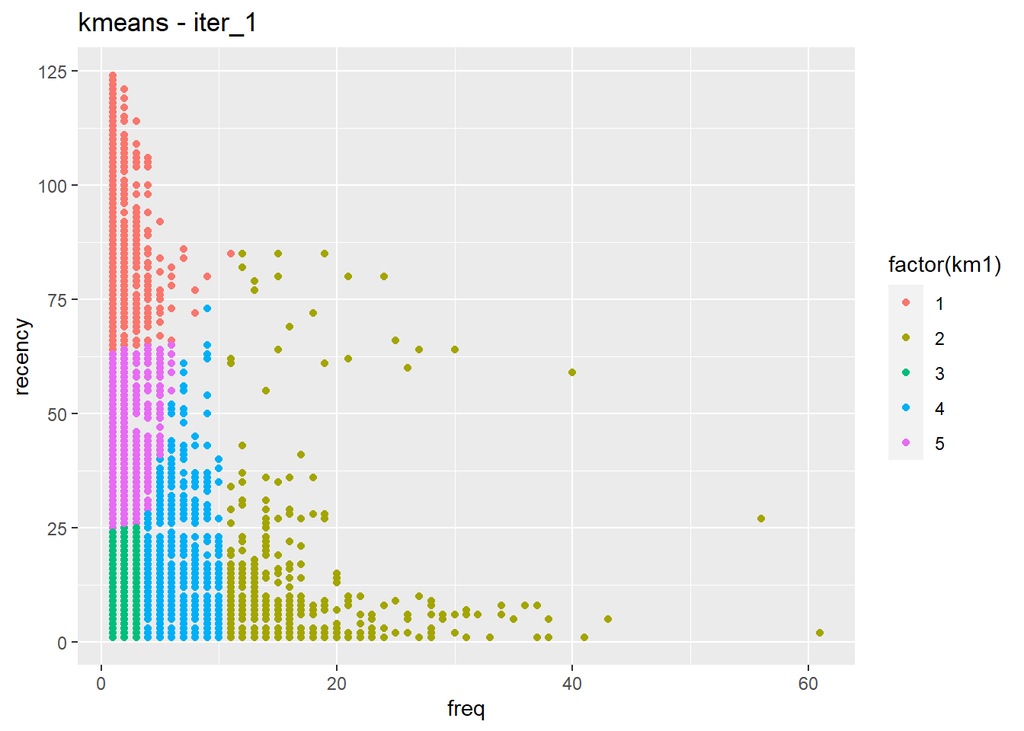

```r
ggplot(data = rfm_customer, aes(x = freq, y = recency, color = factor(km1))) +
    geom_point() +
    ggtitle('kmeans - iter_1')
```

### 6.1.3 Second try (because skewed data and k-means weakness)

```r
set.seed(11234)
seg_km2 <- kmeans(rfm_customer_2, centers = 5)
```

### 6.1.4 Results

```r
table(seg_km2$cluster)  # different cluster sizes with km1 -> different clustering results
```

```
##
##    1    2    3    4    5
## 8615  817 3447  214 1871
```

```r
table(seg_km1$cluster)  # Note: do not care to cluster labels; because they can vary in each run
```

```
##
##    1    2    3    4    5
## 2563  557 6034 2245 3565
```

```r
km_res2 <- as.data.frame(seg_km2$cluster)
km_res2$customer_id <- rownames(km_res2)
colnames(km_res2) <- c('cluster', 'customer_id')

rfm_customer$km2 <- km_res2[,'cluster']
head(rfm_customer)
```

|  | freq | recency | monetary | km1 | km2 |
| --- | --- | --- | --- | --- | --- |
| 5.94687E+23 | 2 | 9 | 680000 | 3 | 1 |
| 5.94772E+23 | 1 | 64 | 600000 | 1 | 3 |
| 5.94773E+23 | 5 | 9 | 1700000 | 4 | 5 |
| 5.95E+25 | 1 | 5 | 320000 | 3 | 1 |
| 58a4b0e452faff000179dbd0 | 7 | 7 | 1480000 | 4 | 5 |
| 58a56a6b52faff00013072d8 | 4 | 37 | 1220000 | 5 | 5 |

```r
aggregate(rfm_customer[,c(1:3)], list(rfm_customer$km2), mean)  # do not care to labels
```

| Group.1 | freq | recency | monetary |
| --- | --- | --- | --- |
| 1 | 1.537551 | 17.261172 | 550056.9 |
| 2 | 10.359853 | 9.977968 | 3575250.9 |
| 3 | 1.371047 | 79.907166 | 467896.7 |
| 4 | 21.570093 | 10.144860 | 7290747.7 |
| 5 | 5.069482 | 11.707108 | 1767300.9 |

> Completely different Clusters!

```r
table(rfm_customer$km2)
```

```
##
##    1    2    3    4    5
## 8615  817 3447  214 1871
```

Visualize clusters

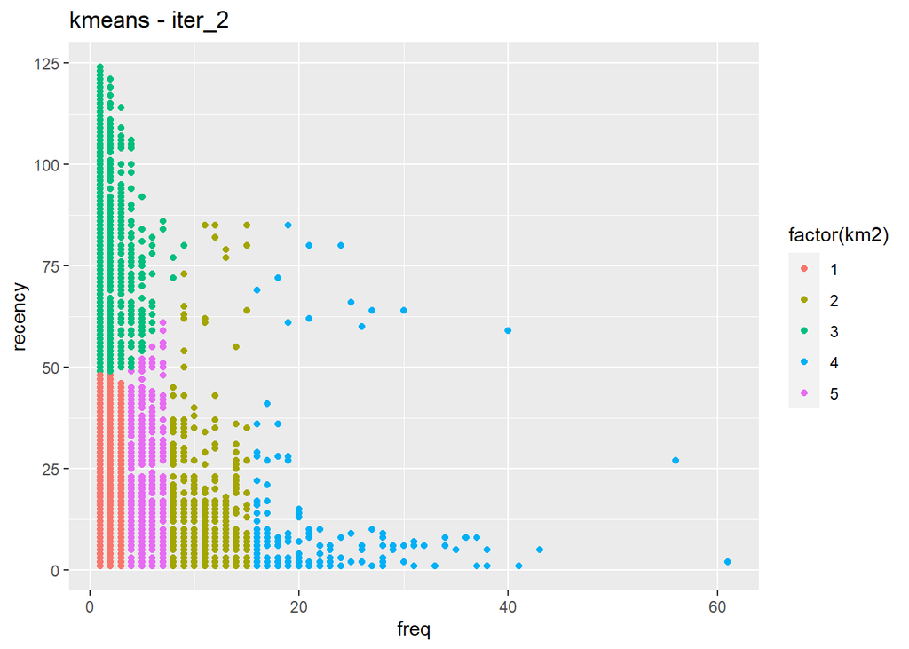

```r
ggplot(data = rfm_customer, aes(x = freq, y = recency, color = factor(km2))) +
    geom_point() +
    ggtitle('kmeans - iter_2')  # too much difference between Clusters in km1 and km2 -> results are not robust!
```

## 6.2 Model 2: CLARA

### 6.2.1 First try

```r
set.seed(1234)
seg_cl1 <- cluster::clara(rfm_customer_2, k = 5, samples = 10000, pamLike = T)
```

### 6.2.2 Results

```r
table(seg_cl1$cluster)  # 5 Clusters
```

```
##
##    1    2    3    4    5
## 4879 2787 2793 3474 1031
```

```r
cl_res1 <- as.data.frame(seg_cl1$cluster)  # cluster labels
cl_res1$customer_id <- rownames(cl_res1)
colnames(cl_res1) <- c('cluster', 'customer_id')

rfm_customer$cl1 <- cl_res1[,'cluster']
head(rfm_customer)
```

|  | freq | recency | monetary | km1 | km2 | cl1 |
| --- | --- | --- | --- | --- | --- | --- |
| 5.94687E+23 | 2 | 9 | 680000 | 3 | 1 | 1 |
| 5.94772E+23 | 1 | 64 | 600000 | 1 | 3 | 2 |
| 5.94773E+23 | 5 | 9 | 1700000 | 4 | 5 | 3 |
| 5.95E+25 | 1 | 5 | 320000 | 3 | 1 | 1 |
| 58a4b0e452faff000179dbd0 | 7 | 7 | 1480000 | 4 | 5 | 3 |
| 58a56a6b52faff00013072d8 | 4 | 37 | 1220000 | 5 | 5 | 4 |

```r
aggregate(rfm_customer[,c(1:3)], list(rfm_customer$cl1), mean)
```

| Group.1 | freq | recency | monetary |
| --- | --- | --- | --- |
| 1 | 1.332240 | 9.567534 | 480475.5 |
| 2 | 1.330822 | 86.055974 | 452759.2 |
| 3 | 4.358754 | 10.018618 | 1522764.1 |
| 4 | 1.460564 | 37.866724 | 517858.4 |
| 5 | 12.686712 | 10.012609 | 4346459.7 |

```r
table(rfm_customer$cl1)
```

```
##
##    1    2    3    4    5
## 4879 2787 2793 3474 1031
```

Visualize clusters

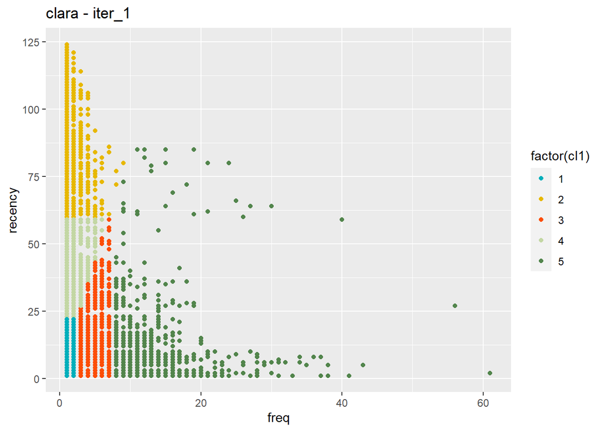

```r
ggplot(data = rfm_customer, aes(x = freq, y = recency, color = factor(cl1))) +
    geom_point() +
    ggtitle('clara - iter_1') +
    scale_color_manual(values = c("#00AFBB", "#E7B800", "#FC4E07", "#C3D7A4", "#52854C"))  # run_1 CLARA result -> similar to run_1 k-means result
```

### 6.2.3 Second try

```r
set.seed(12345678)
seg_cl2 <- cluster::clara(rfm_customer_2, k = 5, samples = 5000, pamLike = T)
```

### 6.2.4 Results

```r
table(seg_cl2$cluster)  # without care to labels: exactly same results with run_1 CLARA (exactly same population in each cluster)
```

```
##
##    1    2    3    4    5
## 4879 2787 2793 3474 1031
```

```r
table(seg_cl1$cluster)
```

```
##
##    1    2    3    4    5
## 4879 2787 2793 3474 1031
```

```r
cl_res2 <- as.data.frame(seg_cl2$cluster)  # cluster labels
cl_res2$customer_id <- rownames(cl_res2)
colnames(cl_res2) <- c('cluster', 'customer_id')

rfm_customer$cl2 <- cl_res2[,'cluster']
head(rfm_customer)
```

|  | freq | recency | monetary | km1 | km2 | cl1 | cl2 |
| --- | --- | --- | --- | --- | --- | --- | --- |
| 5.94687E+23 | 2 | 9 | 680000 | 3 | 1 | 1 | 1 |
| 5.94772E+23 | 1 | 64 | 600000 | 1 | 3 | 2 | 2 |
| 5.94773E+23 | 5 | 9 | 1700000 | 4 | 5 | 3 | 3 |
| 5.95E+25 | 1 | 5 | 320000 | 3 | 1 | 1 | 1 |
| 58a4b0e452faff000179dbd0 | 7 | 7 | 1480000 | 4 | 5 | 3 | 3 |
| 58a56a6b52faff00013072d8 | 4 | 37 | 1220000 | 5 | 5 | 4 | 4 |

```r
aggregate(rfm_customer[,c(1:3)], list(rfm_customer$cl2), mean)  # exact same output result
```

| Group.1 | freq | recency | monetary |
| --- | --- | --- | --- |
| 1 | 1.332240 | 9.567534 | 480475.5 |
| 2 | 1.330822 | 86.055974 | 452759.2 |
| 3 | 4.358754 | 10.018618 | 1522764.1 |
| 4 | 1.460564 | 37.866724 | 517858.4 |
| 5 | 12.686712 | 10.012609 | 4346459.7 |

```r
table(rfm_customer$cl2)
```

```
##
##    1    2    3    4    5
## 4879 2787 2793 3474 1031
```

Visualize clusters

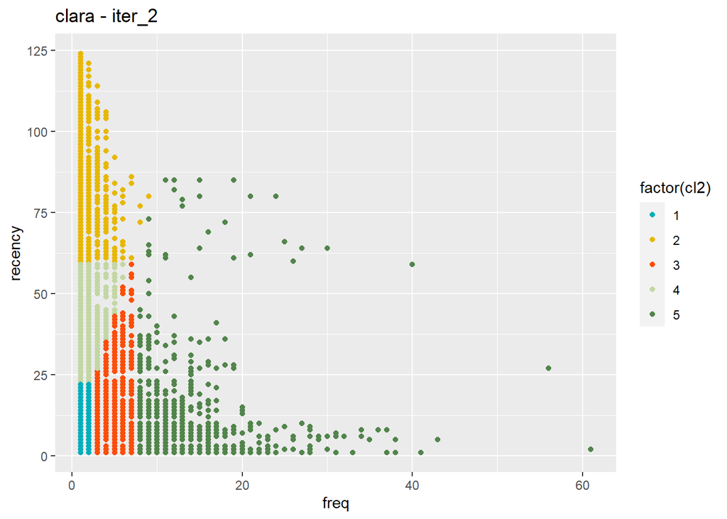

```r
ggplot(data = rfm_customer, aes(x = freq, y = recency, color = factor(cl2))) +
    geom_point() +
    ggtitle('clara - iter_2') +
    scale_color_manual(values = c("#00AFBB", "#E7B800", "#FC4E07", "#C3D7A4", "#52854C"))  # there is no difference (changes) between results cl1 and cl2
```

> result: for this dataset, CLARA is more robust algorithm for Clustering compare to K-Means

## 6.3 Model 3: Hierarchical K-Means

```r
set.seed(1234)
seg_hk1 <- factoextra::hkmeans(rfm_customer_2, k = 5)
```

### 6.3.1 Results

```r
table(seg_hk1$cluster)  # again, different Clustering results -> all results are mathematically True (this is Clustering challenge)
```

```
##
##    1    2    3    4    5
## 6682 3663 1743 2504  372
```

```r
hk_res1 <- as.data.frame(seg_hk1$cluster)
hk_res1$customer_id <- rownames(hk_res1)
colnames(hk_res1) <- c('cluster', 'customer_id')

rfm_customer$hk1 <- hk_res1[,'cluster']
head(rfm_customer)
```

|  | freq | recency | monetary | km1 | km2 | cl1 | cl2 | hk1 |
| --- | --- | --- | --- | --- | --- | --- | --- | --- |
| 5.94687E+23 | 2 | 9 | 680000 | 3 | 1 | 1 | 1 | 1 |
| 5.94772E+23 | 1 | 64 | 600000 | 1 | 3 | 2 | 2 | 2 |
| 5.94773E+23 | 5 | 9 | 1700000 | 4 | 5 | 3 | 3 | 3 |
| 5.95E+25 | 1 | 5 | 320000 | 3 | 1 | 1 | 1 | 1 |
| 58a4b0e452faff000179dbd0 | 7 | 7 | 1480000 | 4 | 5 | 3 | 3 | 3 |
| 58a56a6b52faff00013072d8 | 4 | 37 | 1220000 | 5 | 5 | 4 | 4 | 2 |

```r
aggregate(rfm_customer[,c(1:3)], list(rfm_customer$hk1), mean)
```

| Group.1 | freq | recency | monetary |
| --- | --- | --- | --- |
| 1 | 1.833882 | 9.707273 | 654052.7 |
| 2 | 1.550369 | 40.388752 | 545902.3 |
| 3 | 7.208262 | 10.183592 | 2507228.9 |
| 4 | 1.291134 | 88.687300 | 439145.4 |
| 5 | 18.298387 | 10.056452 | 6181881.7 |

```r
table(rfm_customer$hk1)
```

```
##
##    1    2    3    4    5
## 6682 3663 1743 2504  372
```

Visualize clusters

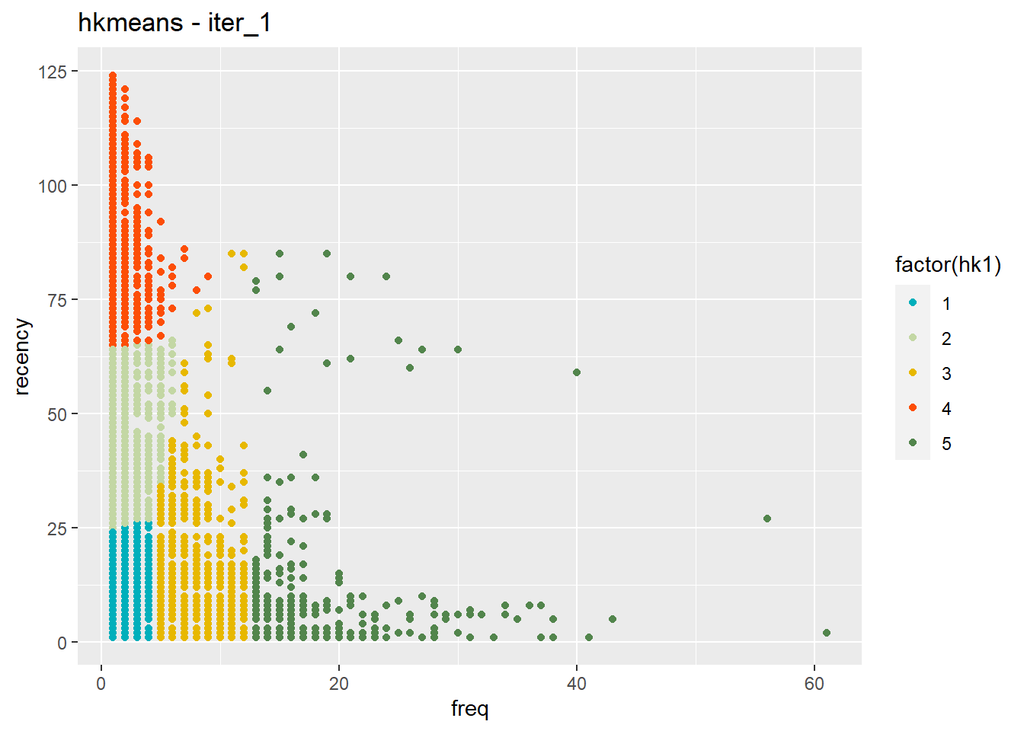

```r
ggplot(data = rfm_customer, aes(x = freq, y = recency, color = factor(hk1)))+
    geom_point() +
    ggtitle("hkmeans - iter_1") +
    scale_color_manual(values = c("#00AFBB", "#C3D7A4", "#E7B800", "#FC4E07", "#52854C"))
```